# Redlining and Biodiversity

Hope Hahn

2023-12-14

## Overview

#### *Background*

Present-day environmental justice may reflect legacies of injustice in the past. The United States has a long history of racial segregation which is still visible. During the 1930’s the Home Owners’ Loan Corporation (HOLC), as part of the New Deal, rated neighborhoods based on their perceived safety for real estate investment. Their ranking system, (A (green), B (blue), C (yellow), D (red)) was then used to block access to loans for home ownership. Colloquially known as “redlining”, this practice has had widely-documented consequences not only for community wealth, but also health.[^1] Redlined neighborhoods have less greenery[^2] and are hotter than other neighborhoods.[^3]

Check out coverage by the [New York Times](https://www.nytimes.com/interactive/2020/08/24/climate/racism-redlining-cities-global-warming.html).

A recent study found that redlining has not only affected the environments communities are exposed to, it has also shaped our observations of biodiversity.[^4] Community or citizen science, whereby individuals share observations of species, is generating an enormous volume of data. Ellis-Soto and co-authors found that redlined neighborhoods remain the most undersampled areas across 195 US cities. This gap is highly concerning, because conservation decisions are made based on these data.

Check out coverage by EOS.

In this analysis, I aim to understand how historical patterns of injustice shapes demographic and environmental conditions of today.

#### *Data*

**EJScreen**

I am working with data from the United States Environmental Protection Agency’s EJScreen: Environmental Justice Screening and Mapping Tool. EJScreen provides on environmental and demographic information for the US at the Census tract and [block group](https://en.wikipedia.org/wiki/Census_block_group) levels. I am working with block group data that has been downloaded from the [EPA site](https://www.epa.gov/ejscreen/download-ejscreen-data).

**Mapping Inequality**

A team of researchers, led by the [Digital Scholarship Lab](https://dsl.richmond.edu/) at the University of Richmond have digitized maps and information from the HOLC as part of the [Mapping Inequality](https://dsl.richmond.edu/panorama/redlining/#loc=5/39.1/-94.58) project.

I am specifically working with maps of HOLC grade designations for Los Angeles. Information on the data can be found [here](https://dsl.richmond.edu/panorama/redlining/#loc=5/39.1/-94.58&text=downloads).[^5]

**Biodiversity observations**

The Global Biodiversity Information Facility is the largest aggregator of biodiversity observations in the world. Observations typically include a location and date that a species was observed. I am only working with observations of birds from 2021 onward.

#### *Highlights of Analysis*

- Investigate the legacy of redlining
  - Visualize wastewater discharge by census block groups
  - Calulate percentage of census groups based on certain conditions
  - Visualize historical redlining boundaries
  - Summarizing historical redlining communities
- Investigate the legacy of redlining in biodiversity observations
  - Visualize percentage of bird observations in redlining communities

## Analysis

#### Investigate the legacy of redlining in current environmental (in)justice

*Data Wrangling*

The first part of this analysis was to read in the EJScreen data and specifically look at LA county. I completed this by filtering for Los Angeles County. Additionally, I found the centroids for each census block group that is above the 95th percentile of national values for wastewater discharge (important to plot later in analysis).

```r
# load packages necessary for analysis
library(tidyverse)
library(sf)
library(tmap)

# set filepath
rootdir <- ("~/Documents/MEDS/COURSES/MEDS_eds223/assignment-2-h-hahn")
datadir <- file.path(rootdir,"data")

# read in EJScreen data
ejscreen <- st_read(file.path(datadir, "EJSCREEN_2023_BG_StatePct_with_AS_CNMI_GU_VI.gdb"))
# filter to los angeles county
los_angeles <- ejscreen %>%
  filter(CNTY_NAME %in% c("Los Angeles County"))

# find centroids for 95%tile wastewater discharge
la_blockgroup_centroids <- st_centroid(los_angeles)

# 95th percentile wastewater discharge centroids
wastewater_centroid1 <- la_blockgroup_centroids %>%
  filter(P_PWDIS > 95)
```

*Visualizing Wastewater Discharge in LA*

I then mapped wastewater discharge by census block groups using the package tmap, and I plotted the centroids of the census block groups that are above the 95th percentile for wastewater discharge. The output demonstrates the volume of wastewater discharge across LA county with points representing areas above the 95th percentile.

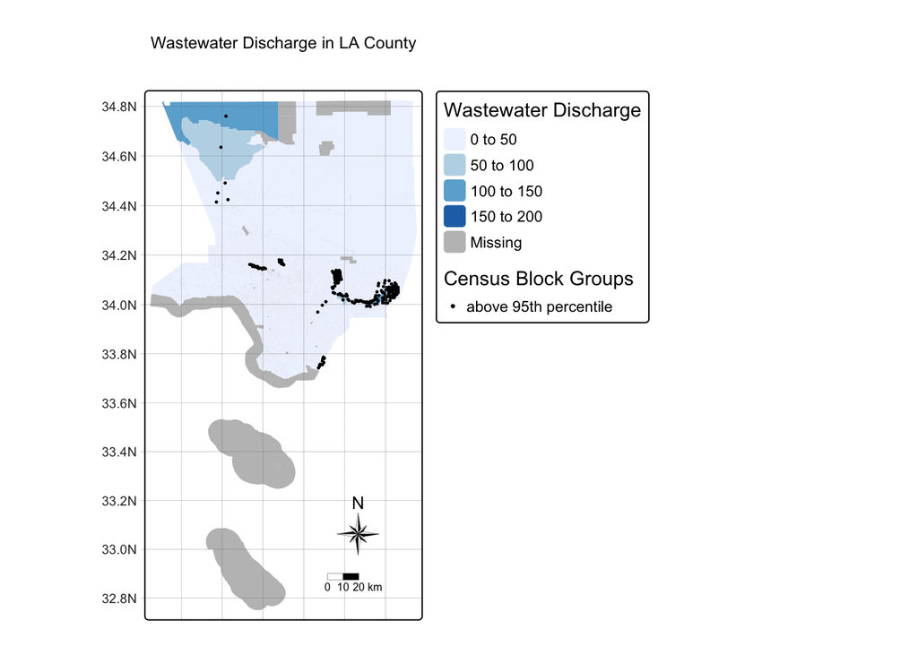

```r
# plot wastewater discharge
tm_shape(los_angeles) + # los angeles data
  tm_polygons('PWDIS', # wastewater data
              lwd = 0.01,
              palette = 'Blues',
              title = "Wastewater Discharge") +
  tm_shape(wastewater_centroid1) + # wastewater centroid above 95 percentile
  tm_dots('P_PWDIS', # percentile wastewater data
          fill = "black",
          size = 0.1) +
  tm_add_legend(type = "dots",
                title = "Census Block Groups",
                labels = c('above 95th percentile'),
                fill = "Black") +
  tm_layout(main.title = "Wastewater Discharge in LA County") + # change title
  tm_compass(type = "8star", # add compass
             size = 2,
             lwd = 0.2) +
  tm_scalebar(lwd = 0.2) + # add scalebar
  tm_graticules(lwd = 0.2) # add graticules
```

*Understanding Characteristics of Census Groups in LA*

To better understand the living conditions of Los Angeles, I performed calculations to find the percent of census groups in Los Angeles that:

- have less than 5% of the population considered low income
- above the 80th percentile for Particulate Matter 2.5 and above the 80th percentile for Superfund proximity.

In order to get these calculations, I filtered for the observations that had these specific values and divided by the total number of observations. I found that 6.11% of the census block groups have less than 5% of the population considered low income, and 17.4% of census block groups are above the 80th percentile for PM 2.5 and above the 80th percentile for Superfund proximity.

```r
# LOWINCPCT is % low income
# % of census block groups that have less than 5% low income
nrow(los_angeles[los_angeles$LOWINCPCT < 0.05,]) / nrow(los_angeles) *100
```

```
## [1] 6.114398
```

```r
# P_PM25 is percentile PM 2.5
# P_PNPL is percentile for superfund proximity
above80 <- los_angeles %>%
  filter(P_PM25 > 80) %>%
  filter(P_PNPL > 80)

# divide number of blocks by total number
nrow(above80) / nrow(los_angeles) *100
```

```
## [1] 17.357
```

*Visualizing Historical Redlining*

The next step was to visualize redlining in Los Angeles. I read in data containing historical redlining data, and mapped the redlining boundaries, colored by HOLC grade.

```r
# import redlining data
LA_redlining <- st_read("https://dsl.richmond.edu/panorama/redlining/static/citiesData/CALosAngeles1939/geojson.json") %>%
  st_make_valid()
```

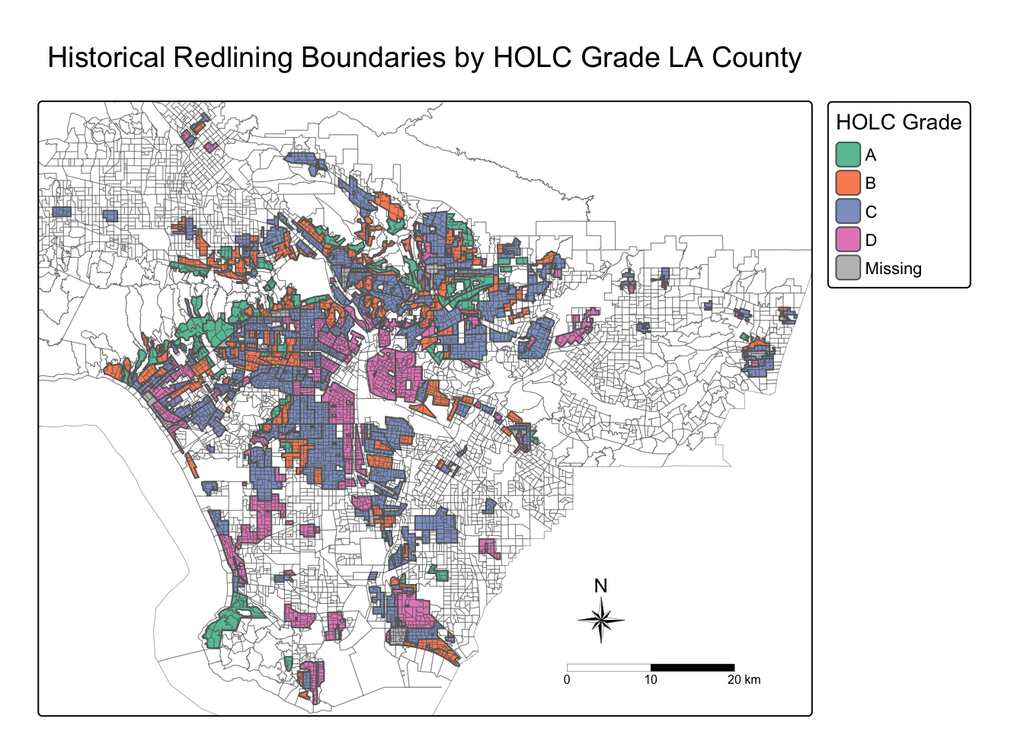

```r
# map historical redlining boundaries
tm_shape(LA_redlining) + # redlining data
  tm_polygons(fill = 'grade', # color by HOLC grade
              palette = ('Set2'),
              title = 'HOLC Grade') +
  tm_shape(los_angeles) + # add whole los angeles
  tm_borders(col_alpha = 0.5, # but just the borders
             lwd = 0.5) +
  tm_layout(main.title = "Historical Redlining Boundaries by HOLC Grade LA County") + # change title
  tm_compass(type = "8star", # add compass
             size = 2,
             lwd = 0.2) +
  tm_scalebar(lwd = 0.2) # add scalebar
```

*Census Block Groups and HOLC Grades*

To calculate the number of census block groups that fall within areas with HOLC grades, I first needed to make sure the CRS of the redlining data and LA county census block group data were the same. Because the CRS differed between the two, I transformed the redlining dataset to match the CRS of the census block group dataset. Next, I found the census block groups that intersected with the redlining data. With this method, I found that 3991 census block groups fall within areas with HOLC grades.

```r
# do the CRS match?
st_crs(los_angeles) == st_crs(LA_redlining)
```

```
## [1] FALSE
```

```r
# CRS doesn't match!

# okay so update CRS to match los_angeles dataset
LA_redlining <- st_transform(LA_redlining, st_crs(los_angeles))

# check that crs match now
st_crs(los_angeles) == st_crs(LA_redlining)
```

```
## [1] TRUE
```

```r
# find intersecting cpg and redlining data
redline_block <- los_angeles[LA_redlining,]

# number of observations in new dataset
nrow(redline_block)
```

```
## [1] 3991
```

*Summary of Historically Redlining Census Block Groups*

The historical redlining data allowed us to understand how historical patterns still influence today’s living conditions. With the new dataset including the historically redlining census block groups, I summarized the current conditions by taking the means of:

- percent low income
- percentile for PM 2.5
- percentile for low life expectancy
- percentile for air toxics cancer risk

Each mean was taken by HOLC grade. These results showed that as the HOLC grades go from A to D, the mean percent of low income increases as well as mean PM 2.5. Additionally the mean of the percentile of low life expectancy and mean percentile of air toxic cancer risk increases from A through D. This means that as the HOLC grades become “lower”, environmental issues seemingly become more prevalent and health risks increase. There are higher rates of low income in “lower” HOLC grades, and higher air particulates and cancer risk. The amount of people with lower life expectancy increases as well, likely due to increasingly worse environmental conditions.

```r
# means by HOLC grade
LA <- st_intersection(LA_redlining, los_angeles)

summary_la <- LA %>%
  group_by(grade) %>%
  summarise(mean_lowinc = mean(LOWINCPCT * 100, na.rm = TRUE),
            mean_pm = mean(P_PM25, na.rm = TRUE),
            mean_lifepct = mean(P_LIFEEXPPCT, na.rm = TRUE),
            mean_cancerpct = mean(P_CANCER, na.rm = TRUE))

print(summary_la)
```

```
## Simple feature collection with 5 features and 5 fields
## Geometry type: MULTIPOLYGON
## Dimension:     XY
## Bounding box:  xmin: -13203640 ymin: 3989343 xmax: -13102620 ymax: 4069679
## Projected CRS: WGS 84 / Pseudo-Mercator
## # A tibble: 5 × 6
##   grade mean_lowinc mean_pm mean_lifepct mean_cancerpct
##   <chr>       <dbl>   <dbl>        <dbl>          <dbl>
## 1 A            15.0    72.2         23.8           44.0
## 2 B            24.2    76.3         37.4           47.7
## 3 C            34.1    78.8         47.9           54.6
## 4 D            39.2    80.2         53.0           56.6
## 5 <NA>         35.8    76.7         50.1           41.5
## # ℹ 1 more variable: geometry <MULTIPOLYGON [m]>
```

#### Investigate the legacy of redlining in biodiversity observations

*Visualize % of Observations in Redlining*

After reading in the bird observation data, I saw that the CRS is not the same between the bird data and redlining data; I converted the bird data into the same CRS as the redlining data so I could find the percent of observations within each redlining category in 2022. I found where the two datasets intersected, saving it into a new dataframe, and then found the percentage of observations by HOLC grade. I plotted the percentages into a bar plot, to visualize the percentage of observations in relation to the other HOLC grades.

The results are surprising because there are higher percent of observations in “lower” HOLC grades than “higher” HOLC grades. This is surprising because one would expect more observations to occur in “better” neighborhoods. As mentioned earlier in the assignment, “lower” HOLC grades have less greenspace, so one would assume there are more birds. A potential implication is that the streets/outdoor spaces in lower HOLC grades have more debris that attract more birds.

```r
# read in bird data
bird <- st_read(file.path(datadir, "gbif-birds-LA"))
# check CRS
st_crs(bird) == st_crs(LA_redlining)
```

```
## [1] FALSE
```

```r
# crs is not the same.... :(

# make CRS same
bird <- st_transform(bird, st_crs(LA_redlining))

# check that CRS is same now
st_crs(bird) == st_crs(LA_redlining)
```

```
## [1] TRUE
```

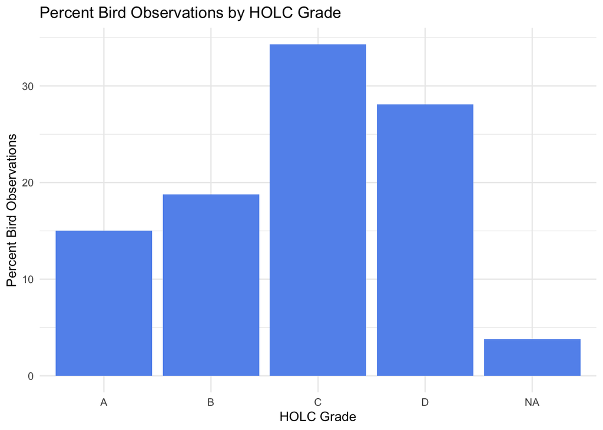

```r
# select only data from 2022
bird_2022 <- bird %>%
  filter(year == 2022)

# join datasets to find overlap
bird_redline <- st_join(LA_redlining, bird_2022, join = st_intersects)

# group by HOLC grade and summarize to find percentage
bird_redline <- bird_redline %>%
  group_by(grade) %>%
  summarise(percent_holc_bird = (n()/nrow(bird_redline))*100) %>%
  st_drop_geometry()

# plot percentage
ggplot(bird_redline,
       aes(x = grade, y = percent_holc_bird)) +
  geom_bar(stat = "identity", fill = "cornflowerblue") +
  labs(title = "Percent Bird Observations by HOLC Grade",
       x = "HOLC Grade",
       y = "Percent Bird Observations") +
  theme_minimal()
```

[^1]: Gee, G. C. (2008). A multilevel analysis of the relationship between institutional and individual racial discrimination and health status. American journal of public health, 98(Supplement_1), S48-S56.
[^2]: Nardone, A., Rudolph, K. E., Morello-Frosch, R., & Casey, J. A. (2021). Redlines and greenspace: the relationship between historical redlining and 2010 greenspace across the United States. Environmental health perspectives, 129(1), 017006.
[^3]: Hoffman, J. S., Shandas, V., & Pendleton, N. (2020). The effects of historical housing policies on resident exposure to intra-urban heat: a study of 108 US urban areas. Climate, 8(1), 12.
[^4]: Ellis-Soto, D., Chapman, M., & Locke, D. H. (2023). Historical redlining is associated with increasing geographical disparities in bird biodiversity sampling in the United States. Nature Human Behaviour, 1-9.
[^5]: Robert K. Nelson, LaDale Winling, Richard Marciano, Nathan Connolly, et al., “Mapping Inequality,” American Panorama, ed. Robert K. Nelson and Edward L. Ayers, accessed October 17, 2023, https://dsl.richmond.edu/panorama/redlining/